# EDA of Loan Data by Amanullah Ashraf

This data set is about the people bought loan. How much is their loan, their credit grade, occupation, income range, loan amout, stated monthly income, employment status etc.

# Univariate Plots Section

## Summary of Loan Status

```
##              Cancelled             Chargedoff              Completed
##                      5                  11992                  38074
##                Current              Defaulted FinalPaymentInProgress
##                  56576                   5018                    205
##   Past Due (>120 days)   Past Due (1-15 days)  Past Due (16-30 days)
##                     16                    806                    265
##  Past Due (31-60 days)  Past Due (61-90 days) Past Due (91-120 days)
##                    363                    313                    304
```

## Summary of Loan Original Amount

```
##    Min. 1st Qu.  Median    Mean 3rd Qu.    Max.
##    1000    4000    6500    8337   12000   35000
```

## Mean, Median

```
## [1] 8337.014
```

```
## [1] 6500
```

## Range of Loan Original Amount

```
## [1]  1000 35000
```

## Range of Stated Monthly Income

```
## [1]       0 1750003
```

## Range of Term Column

```
## [1] 12 60
```

# Plotting histogram of different columns

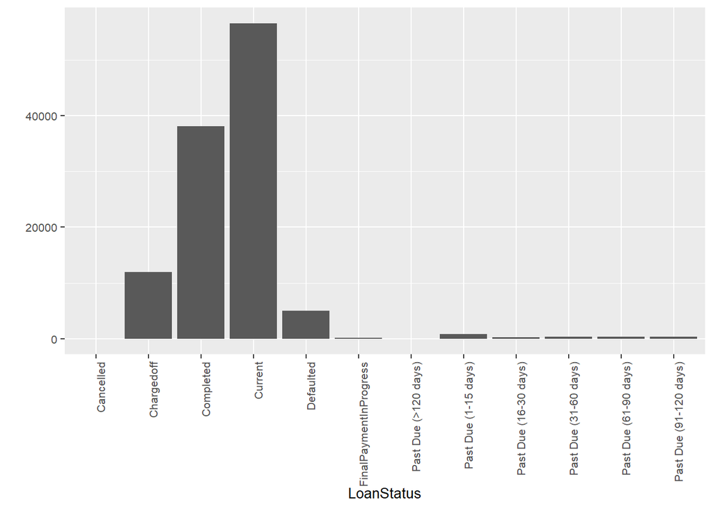

Above graph shows current loan status of the borrower

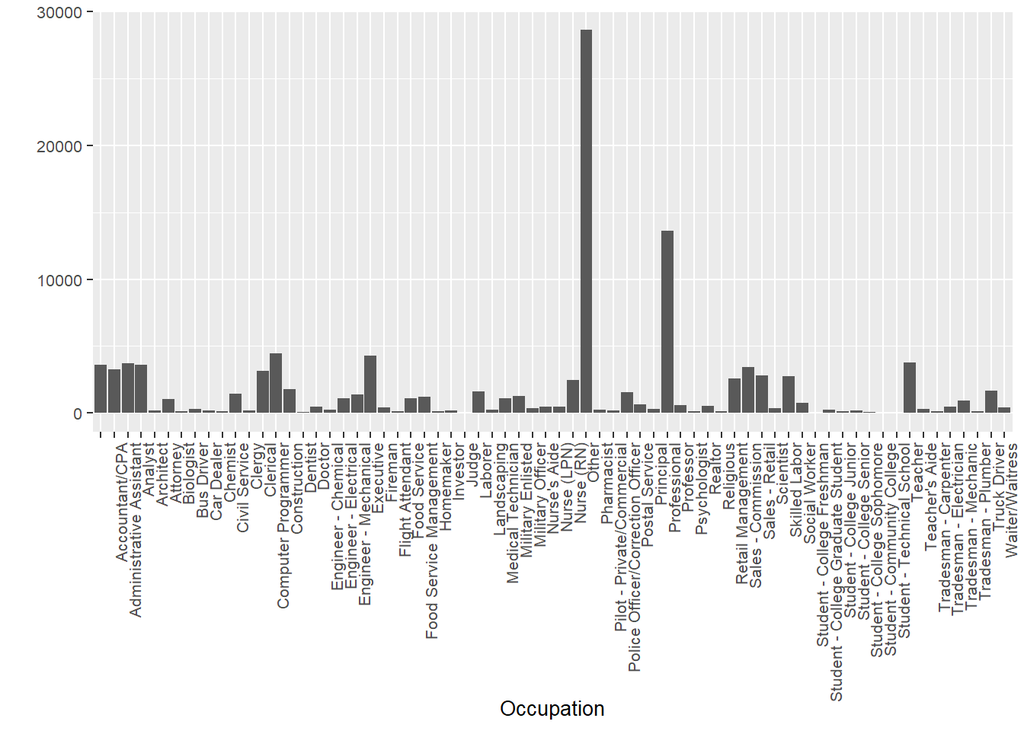

Above graph shows different occupation of the borrowers

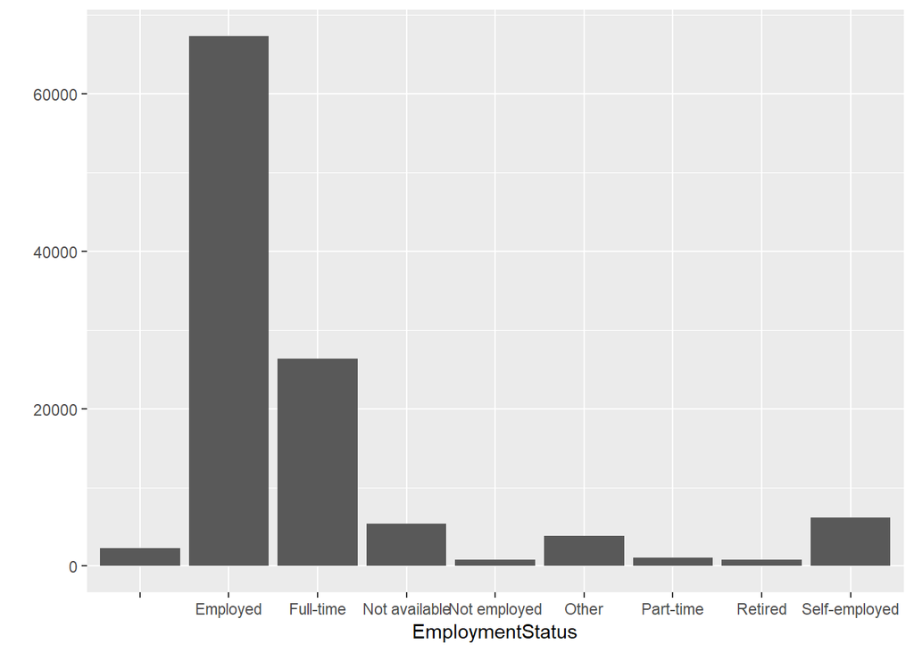

Above graph shows current employment status of the borrower

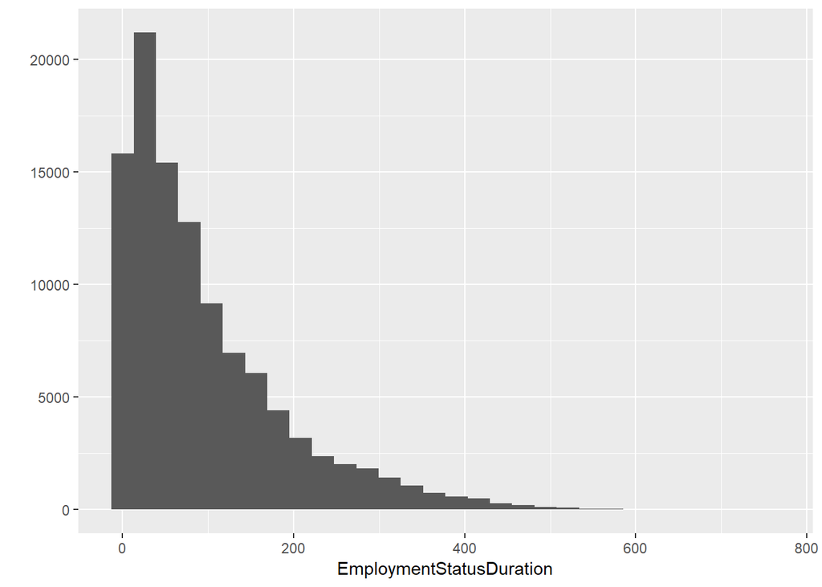

Above graph shows for how long borrower has been employed

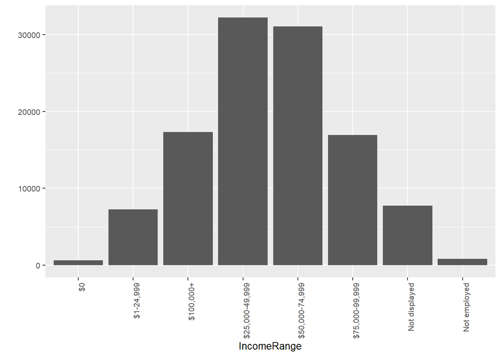

Above graph shows income range of the borrowers

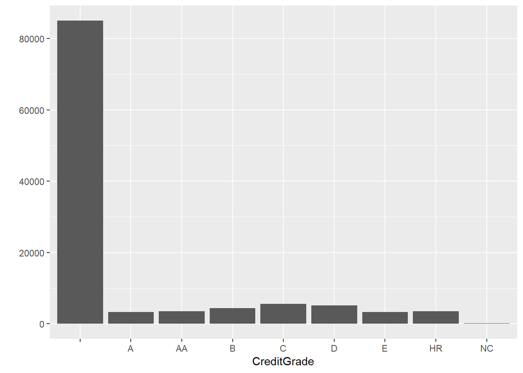

Above graph shows credit grade of the borrower

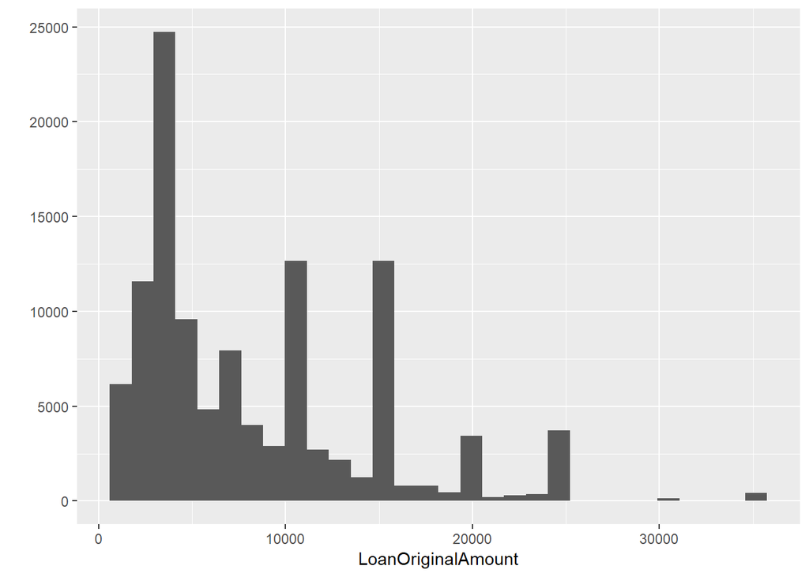

Above graph shows how much loan of original amount taken

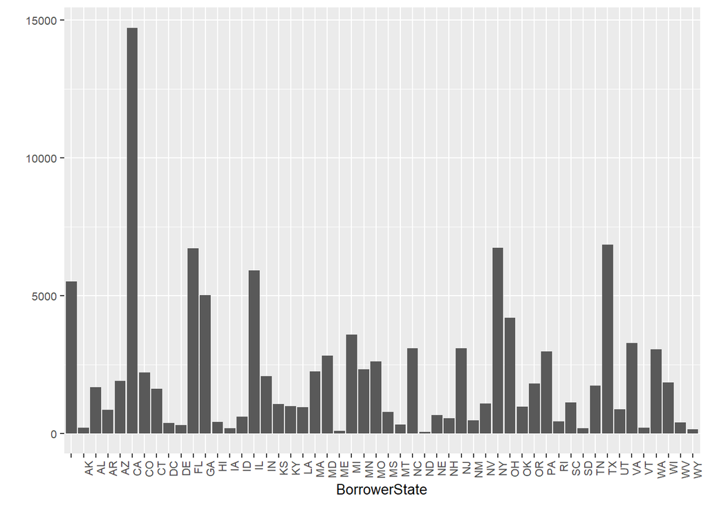

Above plot shows which state has highest borrowing

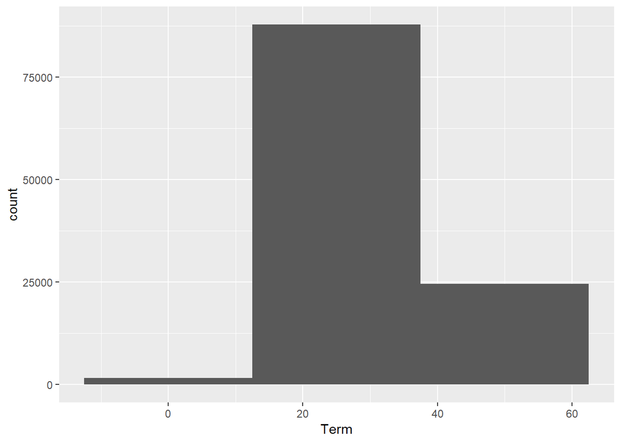

Above plot shows duration of the loan

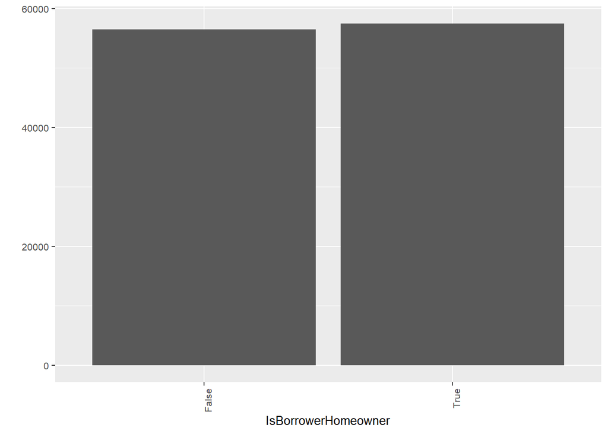

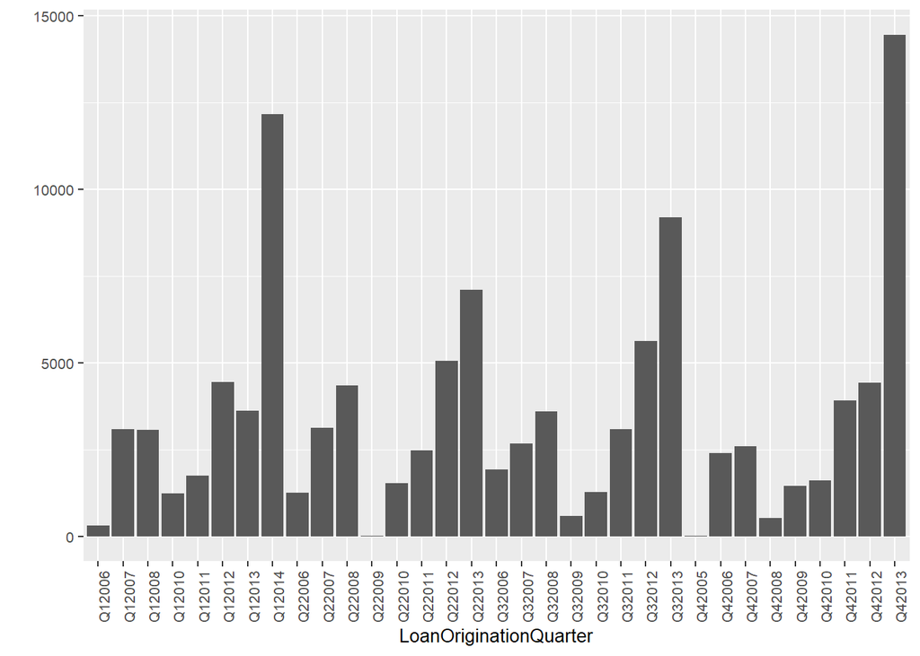

Above graph shows which quarter of the year loan amount was taken

# Univariate Analysis

### What is the structure of your dataset?

Loan data set is compsed of 113937 obersvation and 81 variables. In the data set there

are values which are numceric and other are categorical. It contain information about

peolple who took loan and their current ststus. It contain information about their occupation

thier income, state, credit rating, loan status, employment staus etc.

### What is/are the main feature(s) of interest in your dataset?

Borrower Occupation, thier income range and how much loan original amount they got and how

many have paid them back.

### What other features in the dataset do you think will help support your investigation into your feature(s) of interest?

Other columns like borrower credit rating, borrower state, stated monthly income etc are

helpful as well in investigation.

### Did you create any new variables from existing variables in the dataset?

No new variable is created as data set already contain quite large number of variables.

### Of the features you investigated, were there any unusual distributions? Did you perform any operations on the data to tidy, adjust, or change the form of the data? If so, why did you do this?

Colums which I am using is quite clean. I didnt feel any need to clean it.

# Bivariate Plots Section

## Employment Status wise loan status

```
## ld$EmploymentStatus:
##              Cancelled             Chargedoff              Completed
##                      3                    291                   1439
##                Current              Defaulted FinalPaymentInProgress
##                      0                    522                      0
##   Past Due (>120 days)   Past Due (1-15 days)  Past Due (16-30 days)
##                      0                      0                      0
##  Past Due (31-60 days)  Past Due (61-90 days) Past Due (91-120 days)
##                      0                      0                      0
## --------------------------------------------------------
## ld$EmploymentStatus: Employed
##              Cancelled             Chargedoff              Completed
##                      0                   3529                  12332
##                Current              Defaulted FinalPaymentInProgress
##                  48929                    630                    177
##   Past Due (>120 days)   Past Due (1-15 days)  Past Due (16-30 days)
##                     14                    675                    226
##  Past Due (31-60 days)  Past Due (61-90 days) Past Due (91-120 days)
##                    293                    262                    255
## --------------------------------------------------------
## ld$EmploymentStatus: Full-time
##              Cancelled             Chargedoff              Completed
##                      1                   5343                  17397
##                Current              Defaulted FinalPaymentInProgress
##                   1316                   2217                     10
##   Past Due (>120 days)   Past Due (1-15 days)  Past Due (16-30 days)
##                      0                     28                      7
##  Past Due (31-60 days)  Past Due (61-90 days) Past Due (91-120 days)
##                     13                     11                     12
## --------------------------------------------------------
## ld$EmploymentStatus: Not available
##              Cancelled             Chargedoff              Completed
##                      1                   1065                   3077
##                Current              Defaulted FinalPaymentInProgress
##                      0                   1204                      0
##   Past Due (>120 days)   Past Due (1-15 days)  Past Due (16-30 days)
##                      0                      0                      0
##  Past Due (31-60 days)  Past Due (61-90 days) Past Due (91-120 days)
##                      0                      0                      0
## --------------------------------------------------------
```

[output cut: 34 more lines]

```
##                     92                     58                      0
##   Past Due (>120 days)   Past Due (1-15 days)  Past Due (16-30 days)
##                      0                      2                      0
##  Past Due (31-60 days)  Past Due (61-90 days) Past Due (91-120 days)
##                      2                      1                      1
## --------------------------------------------------------
## ld$EmploymentStatus: Self-employed
##              Cancelled             Chargedoff              Completed
##                      0                    897                   1783
##                Current              Defaulted FinalPaymentInProgress
##                   3085                    246                     10
##   Past Due (>120 days)   Past Due (1-15 days)  Past Due (16-30 days)
##                      2                     44                     13
##  Past Due (31-60 days)  Past Due (61-90 days) Past Due (91-120 days)
##                     22                     19                     13
```

## This shows LoanStatus wise LoanOriginalAmount where loan is still due

```
## ld$LoanStatus == "Current": FALSE
##    Min. 1st Qu.  Median    Mean 3rd Qu.    Max.
##    1000    2800    4500    6341    8000   35000
## --------------------------------------------------------
## ld$LoanStatus == "Current": TRUE
##    Min. 1st Qu.  Median    Mean 3rd Qu.    Max.
##    2000    4000   10000   10361   15000   35000
```

# Checking Relationship between different vriables

## Checking Relationship between StatedMonthlyIncome & LoanOriginalAmount

```
##
##  Pearson's product-moment correlation
##
## data:  ld$StatedMonthlyIncome and ld$LoanOriginalAmount
## t = 69.353, df = 113940, p-value < 2.2e-16
## alternative hypothesis: true correlation is not equal to 0
## 95 percent confidence interval:
##  0.1956816 0.2068243
## sample estimates:
##       cor
## 0.2012595
```

## Checking Relationship between Term & LoanOriginalAmount

```
##
##  Pearson's product-moment correlation
##
## data:  ld$Term and ld$LoanOriginalAmount
## t = 121.6, df = 113940, p-value < 2.2e-16
## alternative hypothesis: true correlation is not equal to 0
## 95 percent confidence interval:
##  0.3337778 0.3440569
## sample estimates:
##       cor
## 0.3389275
```

## Checking Relationship between EmploymentStatusDuration & LoanOriginalAmount

```
##
##  Pearson's product-moment correlation
##
## data:  ld$EmploymentStatusDuration and ld$LoanOriginalAmount
## t = 32.157, df = 106310, p-value < 2.2e-16
## alternative hypothesis: true correlation is not equal to 0
## 95 percent confidence interval:
##  0.09219259 0.10409908
## sample estimates:
##        cor
## 0.09814935
```

## Checking Relationship between StatedMonthlyIncome & EmploymentStatusDuration

```
##
##  Pearson's product-moment correlation
##
## data:  ld$StatedMonthlyIncome and ld$EmploymentStatusDuration
## t = 22.824, df = 106310, p-value < 2.2e-16
## alternative hypothesis: true correlation is not equal to 0
## 95 percent confidence interval:
##  0.06384602 0.07580971
## sample estimates:
##        cor
## 0.06983037
```

# Histogram of 2 variables

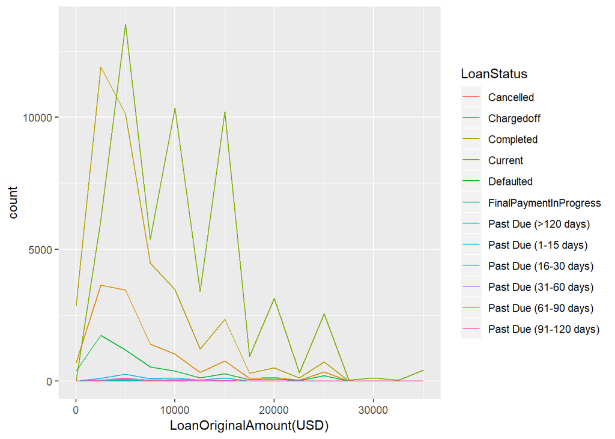

The above graph showes borrower loan status and their loan original amount in order to check the current status, defaulters and who had alreay paid the amount.

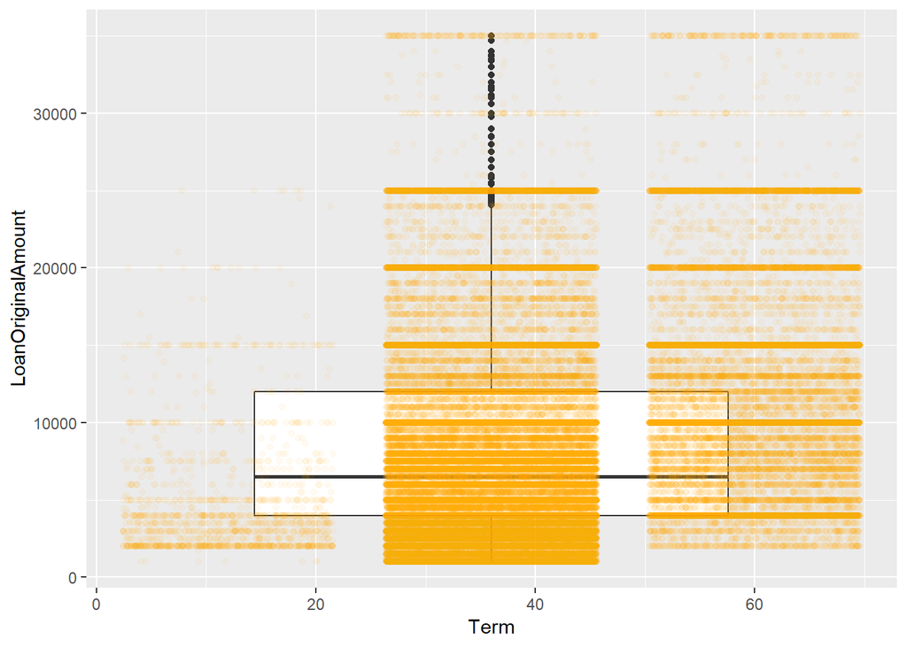

This box plot is showing 5 number summary of Term column against Loan original amount.

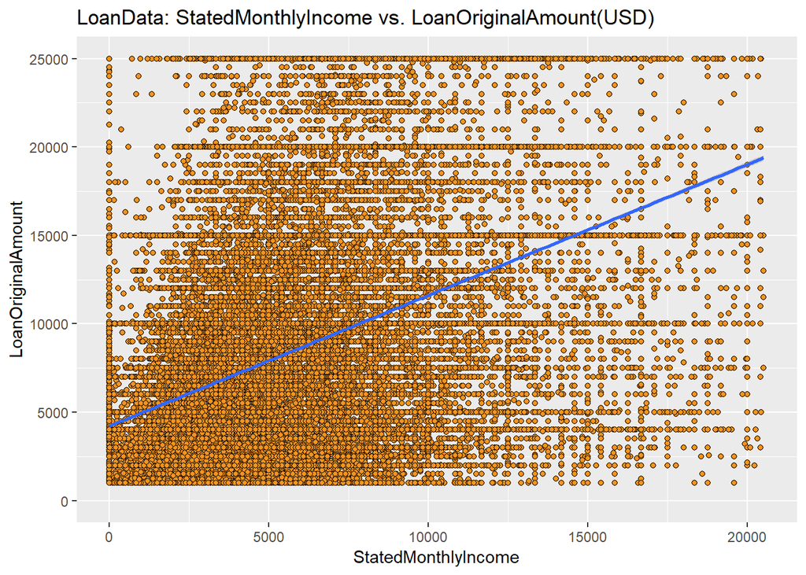

This scatter plot shows borrower original Loan amount and their montly income, inorder to find out the loan trend among the monthly income borrowers. As the monthly rises, loan amount is also rising with it. Means, more monthly income you have, more loan amount you can get.

```
## # A tibble: 52 x 2
##    BorrowerState   mean
##    <fct>          <dbl>
##  1 ""             5412.
##  2 AK             9312.
##  3 AL             7556.
##  4 AR             7697.
##  5 AZ             8200.
##  6 CA             8974.
##  7 CO             8599.
##  8 CT             9130.
##  9 DC            10126.
## 10 DE             8841.
## # ... with 42 more rows
```

```
## # A tibble: 9 x 2
##   EmploymentStatus  mean
##   <fct>            <dbl>
## 1 ""               4563.
## 2 Employed         9794.
## 3 Full-time        6195.
## 4 Not available    5373.
## 5 Not employed     4873.
## 6 Other            6862.
## 7 Part-time        4089.
## 8 Retired          4784.
## 9 Self-employed    8123.
```

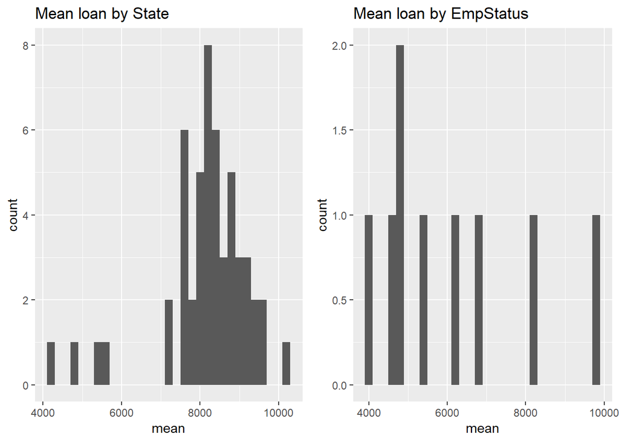

Plotting side by side in order to view Mean of loan by state and by Employment status.

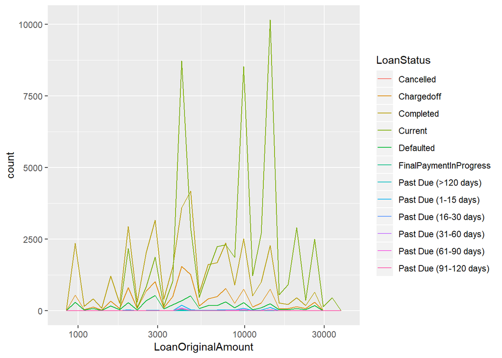

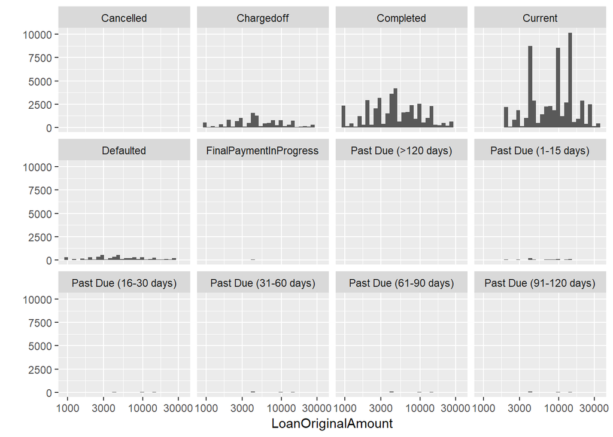

Histogram of loan amount according to loan status

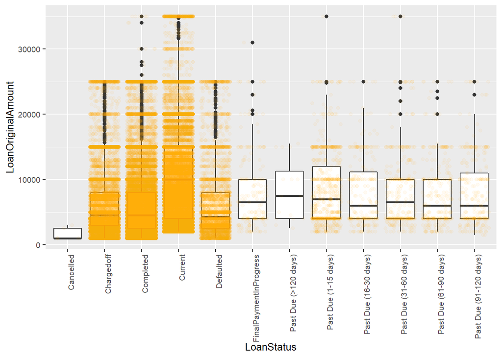

This box plot is showing 5 number summary of loan status colum against loan original amount.

# Bivariate Analysis

### Talk about some of the relationships you observed in this part of the investigation. How did the feature(s) of interest vary with other features in the dataset?

I tried to find out the different combination of coulms with the Loan Status. For example,

Loan Status with loan original amount, loan status with with occupation, loan status with

employment status etc. Drew different kinds of plots.

### Did you observe any interesting relationships between the other features (not the main feature(s) of interest)?

Yes, the relation between EmploymentStatusDuration and LoanOriginalAmount and other one

between StatedMonthlyIncome and EmploymentStatusDuration.

### What was the strongest relationship you found?

The strogest relationship exist between Term and LoanOriginalAmount,

i.e 0.3389275

# Multivariate Plots Section

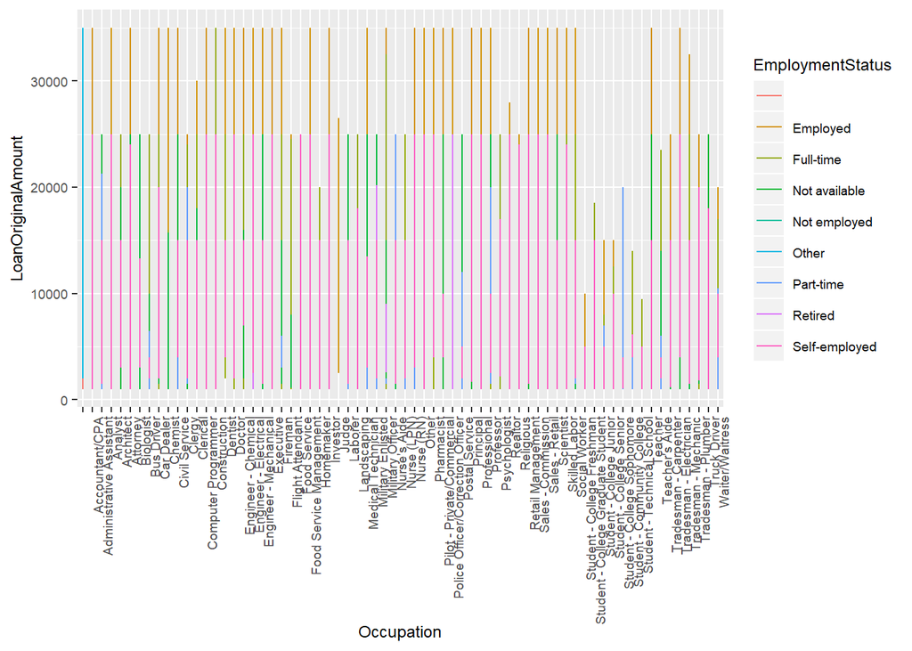

Drwaing line grpah between LoanOriginalAmount, Occupation, EmploymentStatus. This will show the employment status of the borrower, thier occupation and thier loan amount.

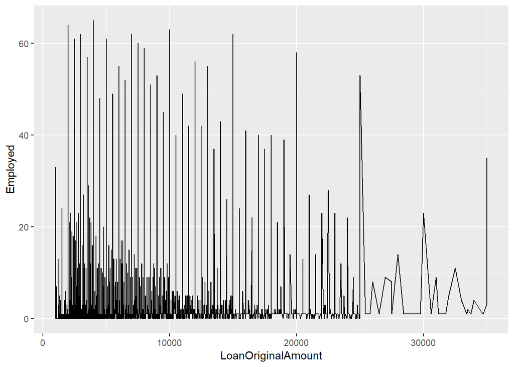

This line graph is showing the employed borrower loan amount. Most of the people on average took below $10,000 loan amount, as there are more black lines in the range of $0 to $10,000

# Multivariate Analysis

### Talk about some of the relationships you observed in this part of the investigation. Were there features that strengthened each other in terms of looking at your feature(s) of interest?

Yes, the relationship between loan amount, employment status and occupation.

### Were there any interesting or surprising interactions between features?

Yes, borrower who are retired were also given loan amount.

### OPTIONAL: Did you create any models with your dataset? Discuss the strengths and limitations of your model.

# Final Plots and Summary

### Plot One

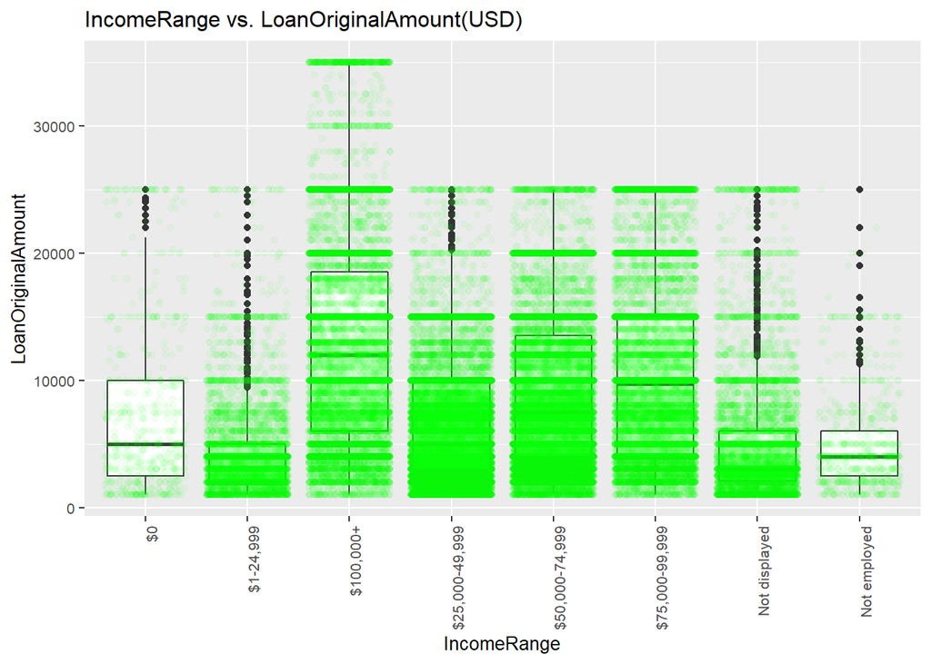

### Description One

Borrower of different income range are shown on the X-axis and their corresponding loan amount are on the Y-axis. From the above graph we can say that there is a kind of symetry of the loan amount taken. Except $100,000+ income range group, almost all other group took, $25000 loan amount. The highest loan amount taken by $100,000 income range group i.e $35,000. They are good traget market segmentation for the lender. Lender can offer them different products inorder to retain them.

### Plot Two

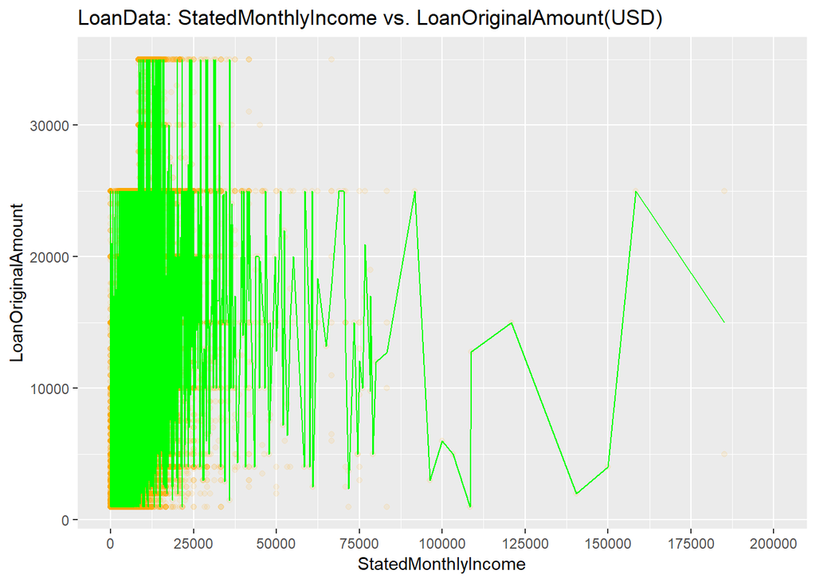

### Plot Three

```
##   LoanOriginalAmount Var.2 Employed Full-time Not available Not employed
## 1               1000     1       33        60            49            2
## 2               1001     1        0         0             4            1
## 3               1005     0        0         1             1            0
## 4               1010     0        0         1             0            0
## 5               1025     1        0         6             6            0
## 6               1030     0        0         3             1            0
##   Other Part-time Retired Self-employed
## 1     1        27       6            27
## 2     0         0       0             0
## 3     0         0       0             0
## 4     0         0       0             0
## 5     0         3       1             0
## 6     0         0       0             0
```

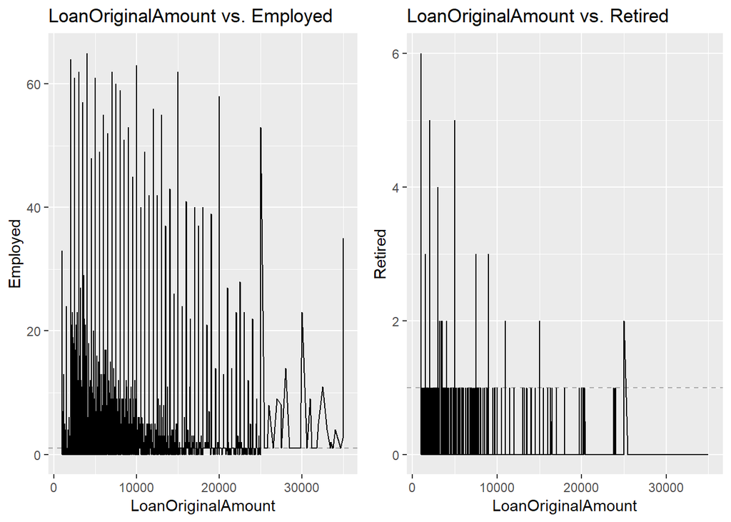

### Description Three

From the above graph we can see that loan amounts were given to both Employed and Retired persons. We can see that loan amount to Retired people were $10000 majority of the times, but people were given in $10,000 to $25000 range as well. employed people are all over the placeses on the graph. This shows that employed people are availaing more loan than retired people. Lender can come up with some good product for employed segment of loan borrower.

# Reflection

Plot 1 shows income range of the people and their borrwed amount. One of the income range group took $35000 loan. They are good traget market for lender. Lender can introduce new products to them, offer discount, offer prizes etc.  
From the above plot 2 we can say that most of the loan are taken by those whose monthly income is from $0 to $25,000. Low imcome are majority who avail the loan opportunity. Plot 3 shows that Employed people are availaing more loan than retired people. Why is that? Are they unable to meet their expenses from their job as they are employed or inflation is high which in turn forced them to take loan? From so many columns it is difficiult to a select few colums for analysis. Good thing about Data set is, it is almost clean, while analyzing. It is a surprises to know that people who are retired also got loan amount.